# 02-Python-Packaging

Let's suppose you're working on a Python project, and you want to turn it into an installable package that you can easily distribute to others (possibly through PyPI).

Python provides a file format for packaging Python libraries/program, known as a *wheel file* (fun fact: PyPI used to be known a long time ago as "The Cheese Shop", and the Python packages therein were called "wheels" in the sense of "wheels of cheese").

Once we've produced a wheel file, we could distribute it directly to our users (e.g., posting it online somewhere or sending it to them via e-mail), but we can also distribute it through PyPI, which means our users will be able to install our software using `pip3`. In these notes, we will see how we would do this to turn the Connect-M example into an installable package on PyPI:

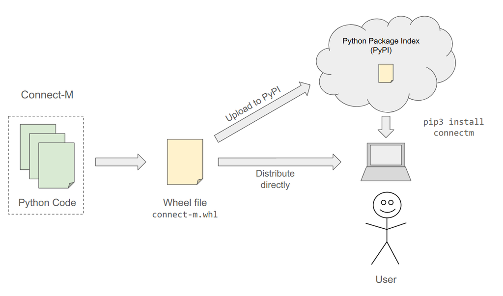

In fact, Connect-M is available on PyPI! You can see it here: https://pypi.org/project/connectm/

# Overview

Turning your Python code into an installable package will involve the following steps.

1. Set up a directory structure for the package (and, if you intend your code to open source, host it on a repository on GitHub or a similar site)
2. Add a `pyproject.toml` configuration file with information about the package.
3. Generate the *distribution files* (installable files you can distribute to others)
4. Optionally, upload your distribution files to PyPI

We describe each of these steps in more detail below.

## Directory Structure

Python does not mandate a specific directory structure for packages, but there are a number of common conventions that you should observe.

### `README.md`

The most important is (arguably) including a `README.md` file in the root of your repository, with an overview of your project, basic instructions on how to use it, etc. This will be the first document that most people will look for and, if it is not present (or is poorly written), it will make your package harder to use.

### `src/`

Source code is often contained inside a `src/` directory, to separate it from other contents (such as documentation, testing code, etc.) That said, another common convention is to include the code inside a directory named after the package. For example, in the Connect-M respository we could've placed the code inside a `connectm/` directory (instead of a `src/` directory)

In the Connect-M example, and in the course project, we are only working with a handful of Python files inside the `src/` directory, but what if we're working on a really big software project with hundreds of Python files?

In that case, it is common to further divide the `src/` repository into subdirectories. For example, we could imagine the Connect-M `src` directory looking like this:

```
connectm/
 ├─ __init__.py
 ├─ logic/
 │   ├─ __init__.py
 │   ├─ board.py
 │   └─ rules.py
 ├─ ui/
 │   ├─ __init__.py
 │   ├─ gui.py
 │   └─ tui.py
 └─ bot/
     ├─ __init__.py
     ├─ cli.py
     └─ strategies/
         ├─ __init__.py
         ├─ random.py
         ├─ basic.py
         └─ minimax.py
```

Suppose that minimax.py included a class called `MiniMaxStrategy`. If we organized our code as shown above, we would import that class like this:

```
from connectm.bot.strategies.minimax import MiniMaxStrategy
```

These kind of directory structures are beyond the scope of this class, but here are some useful tidbits:

- Directories that contain Python code are (a bit confusingly) called "packages". So, directory `connectm/bot/strategies` would be referred to as the `connectm.bot.strategies` package in Python. This "package" is unrelated to the kind of installable software package we are aiming to create.
- Directories representing packages contain an `__init__.py` file (this file can serve many purposes, but you can just think of it as a file that designates a directory as a Python package)
- You can learn more about packages in the [Modules](https://docs.python.org/3/tutorial/modules.html) chapter of the official Python Tutorial.

### `tests/` and `docs/`

It is also common to place all your testing code inside the `tests/` directory, and all your documentation in a `docs/` directory.

### `LICENSE`

The license we are making the code available under should be included in a `LICENSE` text file.

## `pyproject.toml` configuration file

The `pyproject.toml` configuration file contains information about the package, including its dependencies and other information that Python needs to install the package.

This file has a lot of different options we can tweak; the [pyproject.toml file in the Connect-M repository](https://github.com/uchicago-cs/connectm/blob/main/pyproject.toml) highlights some of the main ones:

```
[build-system]
requires = ["setuptools>=67.0"]
build-backend = "setuptools.build_meta"
```

We need to start by specifying what "build system" we will use to generate our distributable files. There are many options available; `setuptools` is a classic option, and generally fine for basic projects.

```
[project]
name = "connectm"
version = "1.1.0"
authors = [
  { name="University of Chicago - Department of Computer Science", email="borja@cs.uchicago.edu" },
]
description = "Connect-M"
readme = "README.md"
requires-python = ">=3.10"
classifiers = [
    "Programming Language :: Python :: 3",
    'License :: OSI Approved :: BSD License',
    "Operating System :: OS Independent",
]
dynamic = ["dependencies"]
```

The `[project]` section includes useful information about the project, including its name, its version, it authors, etc.

```
[tool.setuptools.dynamic]
dependencies = {file = ["requirements.txt"]}
```

This section is required if we are specifying our dependencies in a `requirements.txt` file. We can also specify the dependencies directly in the `pyproject.toml` file like this (under the `[project]` section):

```
dependencies = [
"click==8.1.7",
"colorama==0.4.6",
"mypy==1.7.1",
"mypy-extensions==1.0.0",
"pygame==2.5.2",
"pytest==7.4.3",
"types-colorama==0.4.15.12"
]
```

We can also specify that installing this package should create new terminal commands:

```
[project.scripts]
connectm-gui = "gui:cmd"
connectm-tui = "tui:cmd"
connectm-bot = "bot:cmd"
```

For example, if we install the `connectm` package on our computer, we will have a `connectm-gui` command available in the terminal. `gui:cmd` means "this command should run the `cmd` function in the `gui` module, i.e., in `gui.py`")

Finally, we can include the URL of our repository, etc.:

```
[project.urls]
"Homepage" = "https://github.com/uchicago-cs/connectm"
"Bug Tracker" = "https://github.com/uchicago-cs/connectm/issues"
```

# Generating Distributable Files

After creating the pyproject.toml file, we can run the following command to build our distributable files:

```
python3 -m build
```

Note: Before doing this, you may need to install the `build` module using `pip3 install build`

This will print a fair amount of output, ending with:

```
Successfully built connectm-1.1.0.tar.gz and connectm-1.1.0-py3-none-any.whl
```

There will now be a new directory called dist/ containing the following two files:

- `connectm-1.1.0.tar.gz`: The *source distribution*. This file contains all the source code in our repository, including any tests.
- `connectm-1.1.0-py3-none-any.whl`: A *built distribution* (using the "wheel" format). This file contains only the files that are necessary to use this package. For example, it won't contain all the testing code.

In general, if I wanted to share my package with someone, I'd share the wheel file with them (or make it available for download somewhere)

To install a wheel file, we can just use pip. If you'd like to try this out, we suggest you use a virtual environment (so that the wheel only gets installed in that virtual environment):

```
$ pip3 install connectm-1.0.0-py3-none-any.whl
Processing /home/borja/repos/connectm/dist/connectm-1.1.0-py3-none-any.whl
Collecting mypy-extensions>=1.0.0
  Using cached mypy_extensions-1.0.0-py3-none-any.whl (4.7 kB)
Collecting click>=8.1.7
  Using cached click-8.1.7-py3-none-any.whl (97 kB)
Collecting colorama>=0.4.6
  Using cached colorama-0.4.6-py2.py3-none-any.whl (25 kB)
Collecting pygame>=2.5.2
  Using cached pygame-2.5.2-cp310-cp310-manylinux_2_17_x86_64.manylinux2014_x86_64.whl (14.0 MB)
Collecting mypy>=1.7.1
  Using cached mypy-1.8.0-cp310-cp310-manylinux_2_17_x86_64.manylinux2014_x86_64.whl (12.5 MB)
Collecting types-colorama>=0.4.15.12
  Using cached types_colorama-0.4.15.20240205-py3-none-any.whl (5.8 kB)
Collecting pytest>=7.4.3
  Downloading pytest-8.0.2-py3-none-any.whl (333 kB)
     ━━━━━━━━━━━━━━━━━━━━━━━━━━━━━━━━━━━━━━━━ 334.0/334.0 KB 4.5 MB/s eta 0:00:00
Collecting typing-extensions>=4.1.0
  Using cached typing_extensions-4.9.0-py3-none-any.whl (32 kB)
Collecting tomli>=1.1.0
  Using cached tomli-2.0.1-py3-none-any.whl (12 kB)
Collecting exceptiongroup>=1.0.0rc8
  Using cached exceptiongroup-1.2.0-py3-none-any.whl (16 kB)
Collecting iniconfig
  Using cached iniconfig-2.0.0-py3-none-any.whl (5.9 kB)
Collecting pluggy<2.0,>=1.3.0
  Using cached pluggy-1.4.0-py3-none-any.whl (20 kB)
Collecting packaging
  Using cached packaging-23.2-py3-none-any.whl (53 kB)
Installing collected packages: typing-extensions, types-colorama, tomli, pygame, pluggy, packaging, mypy-extensions, iniconfig, exceptiongroup, colorama, click, pytest, mypy, connectm
Successfully installed click-8.1.7 colorama-0.4.6 connectm-1.1.0 exceptiongroup-1.2.0 iniconfig-2.0.0 mypy-1.8.0 mypy-extensions-1.0.0 packaging-23.2 pluggy-1.4.0 pygame-2.5.2 pytest-8.0.2 tomli-2.0.1 types-colorama-0.4.15.20240205 typing-extensions-4.9.0
```

Notice how pip knows to install all the dependencies as well (because the wheel file internally includes the `pyproject.toml` and `requirements.txt` files, and thus knows what other libraries need to be installed)

Not just that, it also installed the Connect-M commands:

```
$ connectm-bot
Bot 1 (random) wins: 55.78%
Bot 2 (random) wins: 44.00%
Ties: 0.22%
$ connectm-tui

┌─┬─┬─┬─┬─┬─┬─┐
│ │ │ │ │ │ │ │
├─┼─┼─┼─┼─┼─┼─┤
│ │ │ │ │ │ │ │
├─┼─┼─┼─┼─┼─┼─┤
│ │ │ │ │ │ │ │
├─┼─┼─┼─┼─┼─┼─┤
│ │ │ │ │ │ │ │
├─┼─┼─┼─┼─┼─┼─┤
│ │ │ │ │ │ │ │
├─┼─┼─┼─┼─┼─┼─┤
│ │ │ │ │ │ │ │
└─┴─┴─┴─┴─┴─┴─┘

Player 1>
```

## Uploading to PyPI

While you can handle the distribution of wheel files yourself, a better way to make your package easily available is by publishing it on PyPI. All you need is to create an account on PyPI, and then use a tool called `twine` to upload your distribution files to PyPI.

You can see an example of what this looks like on the connectm entry on PyPI: https://pypi.org/project/connectm/ Notice how it includes much of the information we included in the `pyproject.toml` file.

By uploading a package to PyPI, it becomes available through `pip` which means we can now install it like this:

```
$ pip3 install connectm
```

The first lines of output will look like this:

```
Collecting connectm
  Downloading connectm-1.1.0-py3-none-any.whl (16 kB)
```

Notice how pip is using the wheel file we uploaded to PyPI.